# Statistical Report of the SIA Mission 2025

Author

Affiliations

George A. Romero, MD

PAMS

Published

October 8, 2026

Abstract

This report provides a comprehensive statistical summary of the patient data collected during the SIA Mission 2025. The analysis includes descriptive statistics, highlighting key demographic trends, health outcomes, and the prevalence of conditions observed among the participants. By presenting these findings, the report aims to offer valuable insights into the population served and to support future healthcare planning and interventions in similar missions.

~SIA~Selva in Action2025

716

Patients attended

Communities reached

54%

Female patients

386 women · 329 men

With SIS insurance

632 patients

30%

First-time patients

205 new · 476 returning

33

Median age (years)

n = 401 with known date of birth

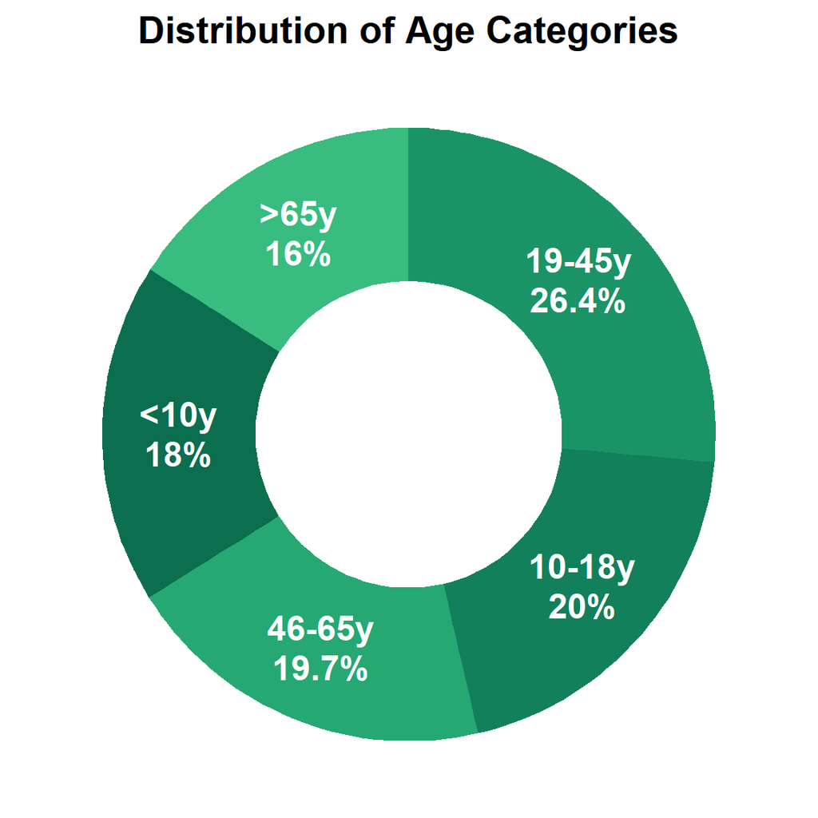

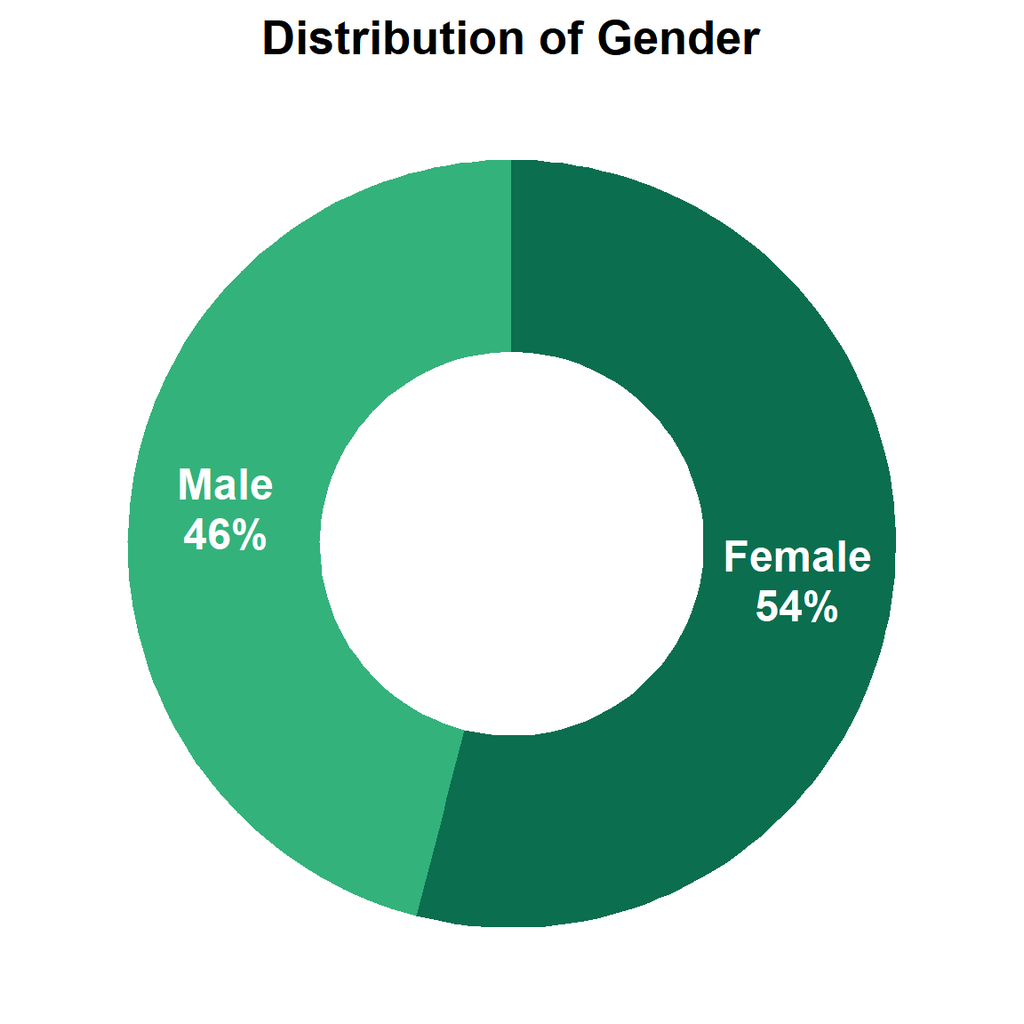

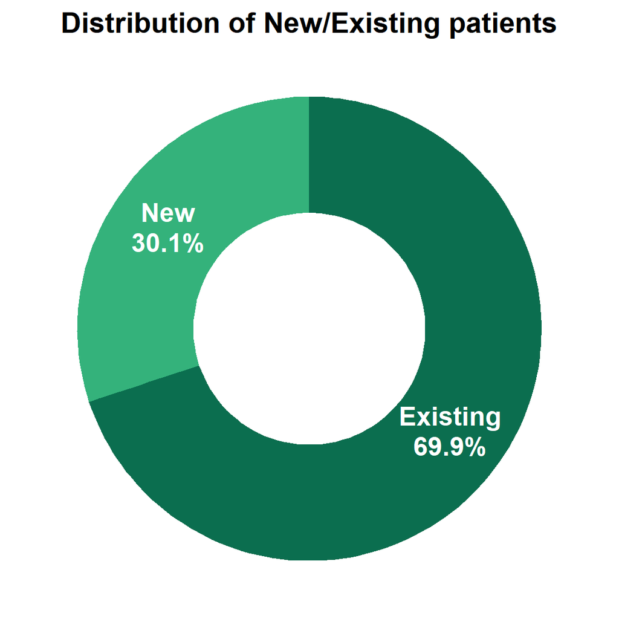

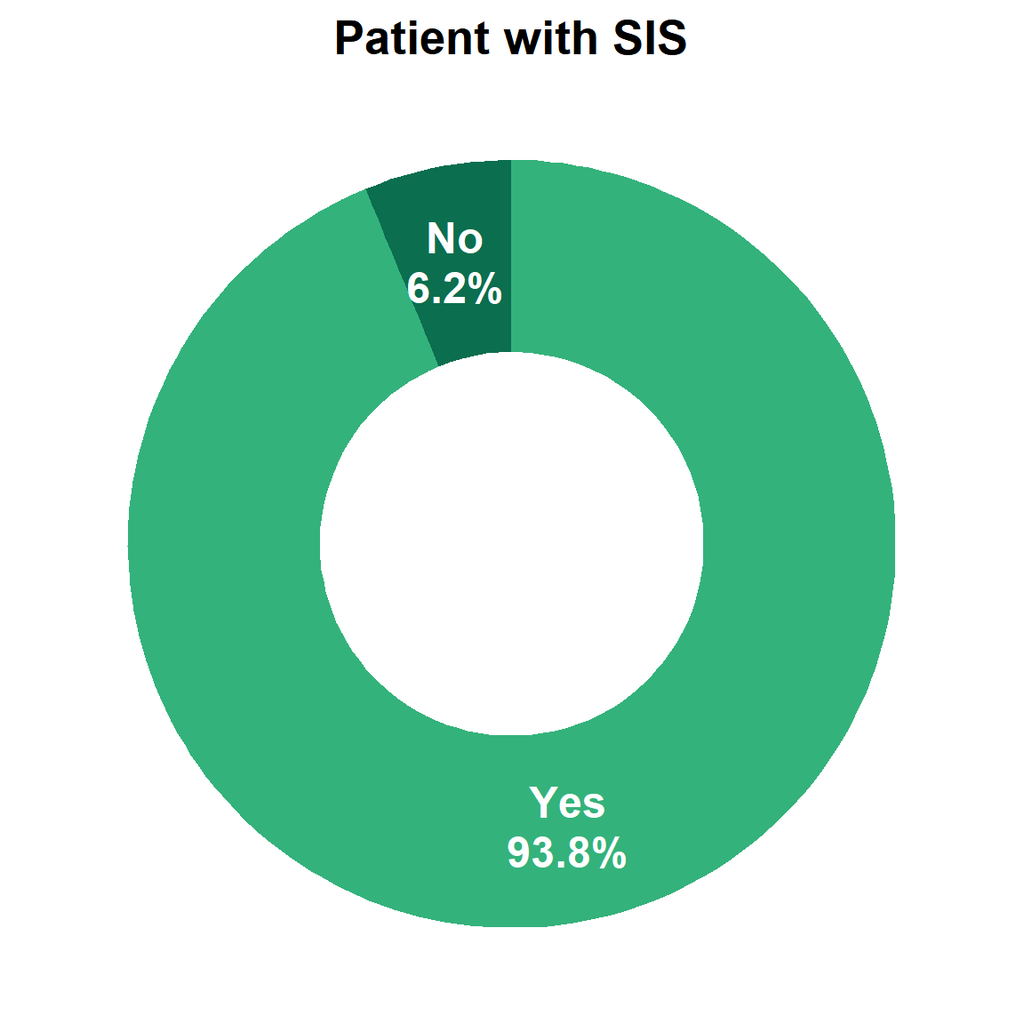

The following section presents the results of the descriptive analysis in the form of questions for better understanding and interpretation.

**TipWhat were the most common diagnoses in the mission?**

**General**

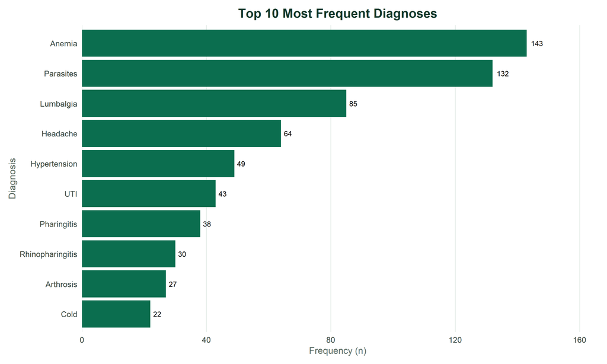

**By age**

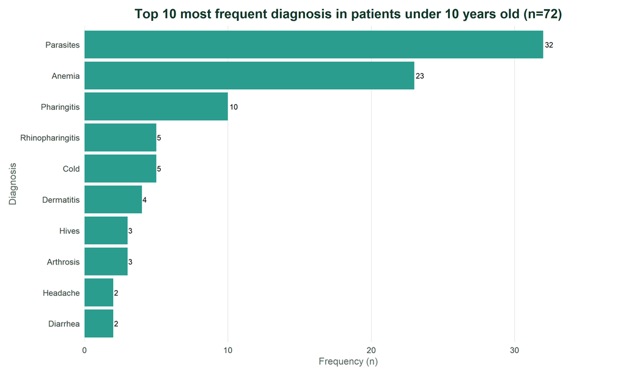

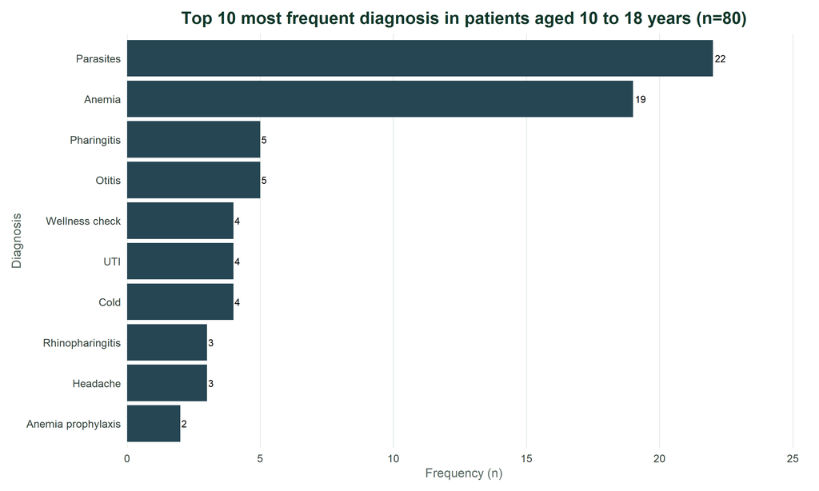

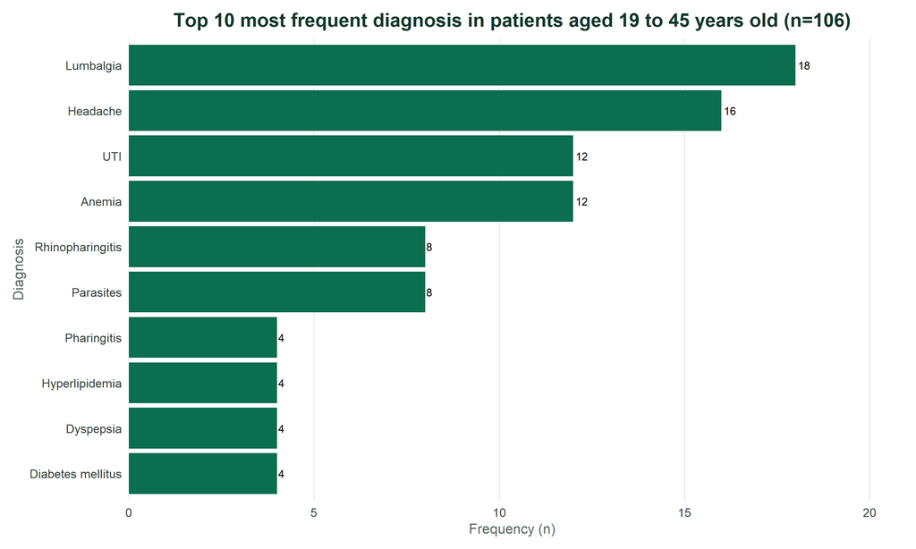

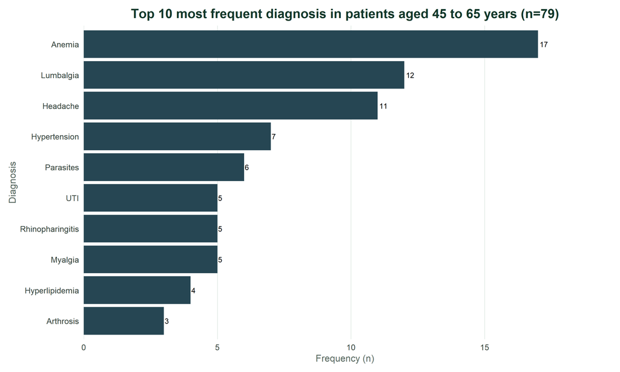

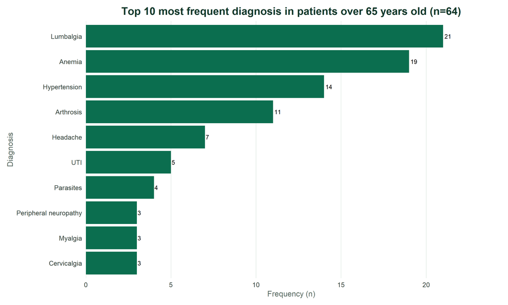

**By gender**

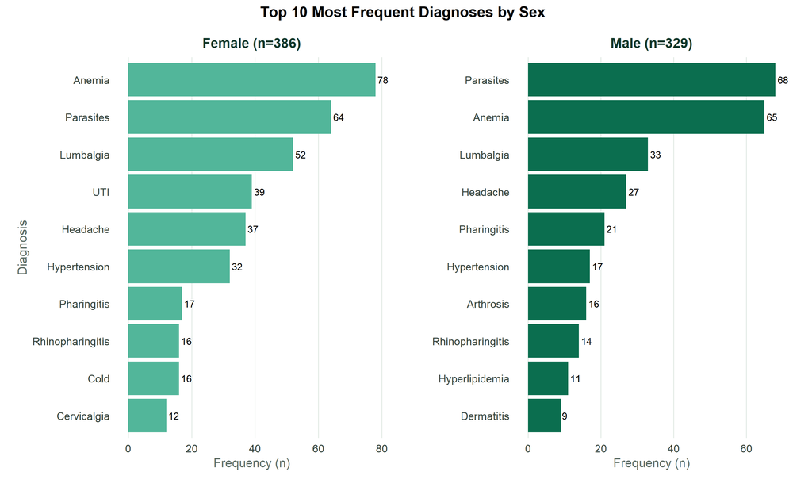

**TipWhat were the most prescribed medications?**

**General**

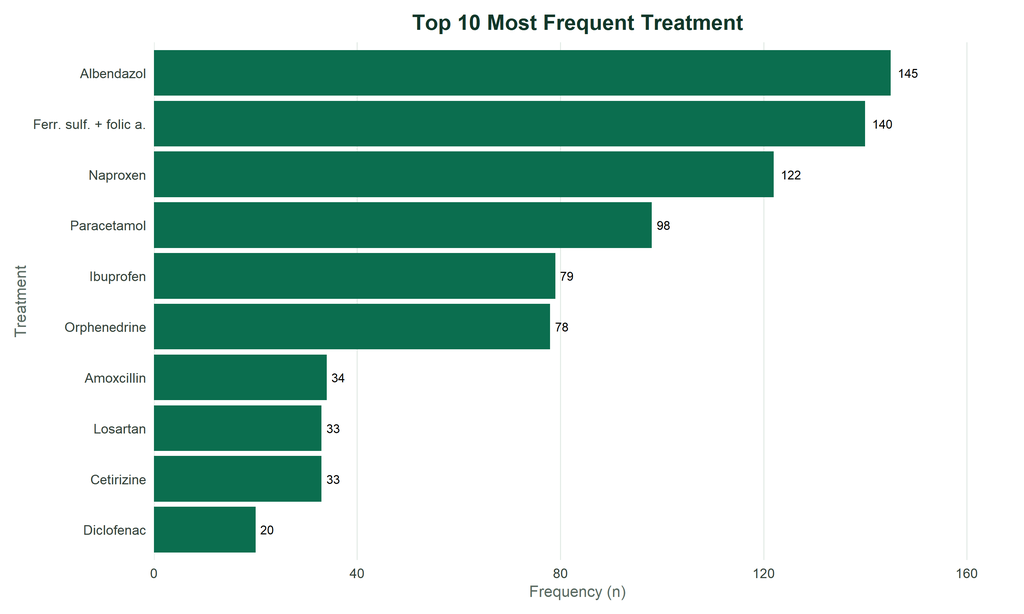

**By age**

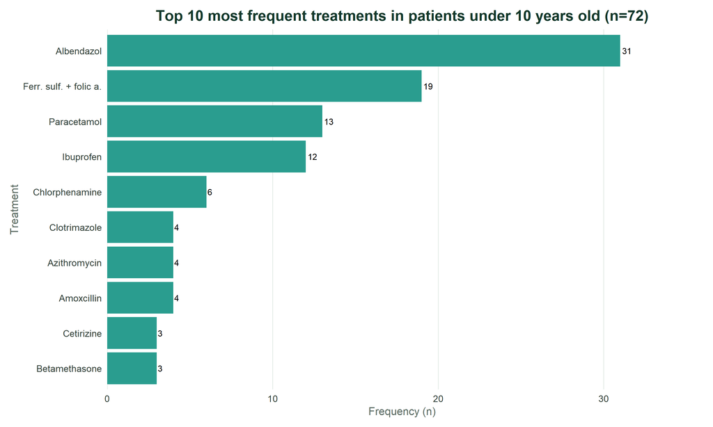

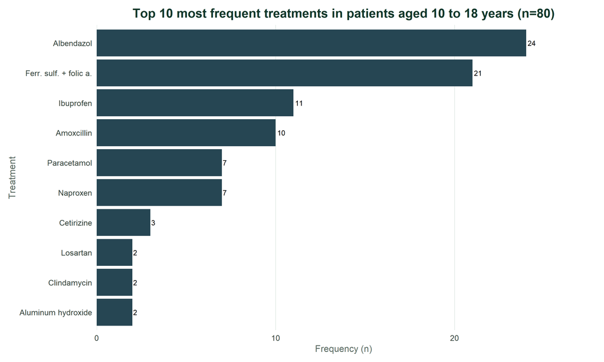

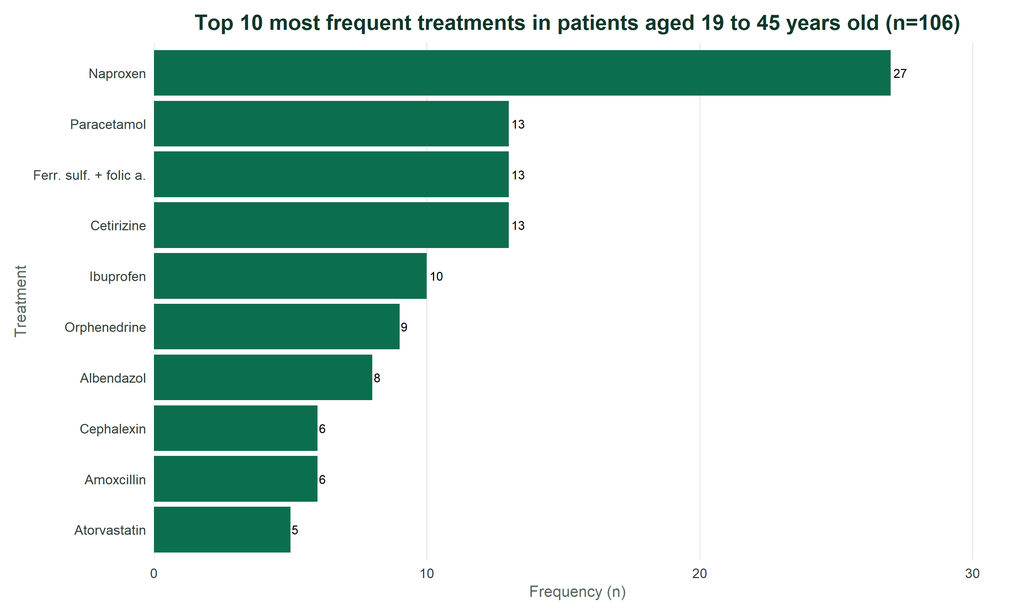

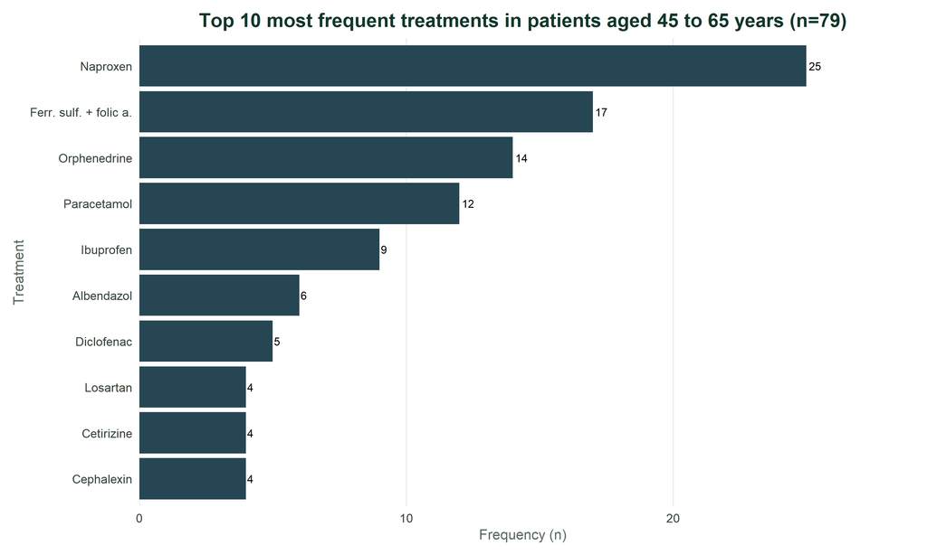

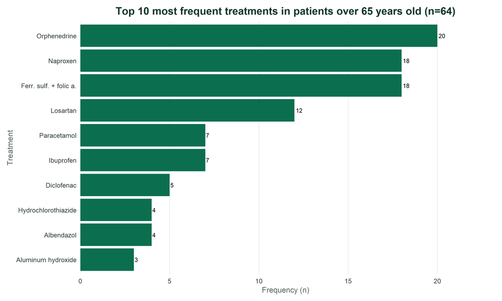

**By gender**

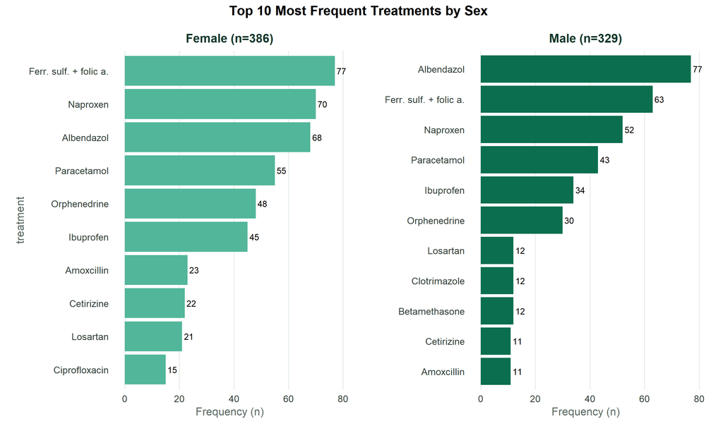

**TipWhat is the percentage of anemia in the population served?**

**General**

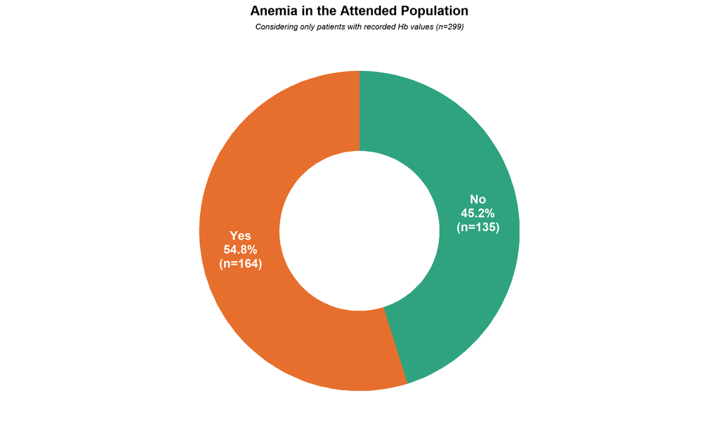

**By age**

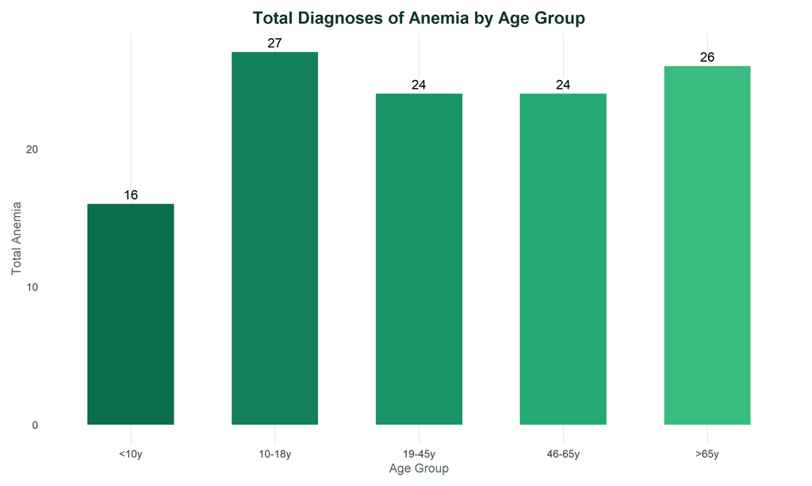

**By gender**

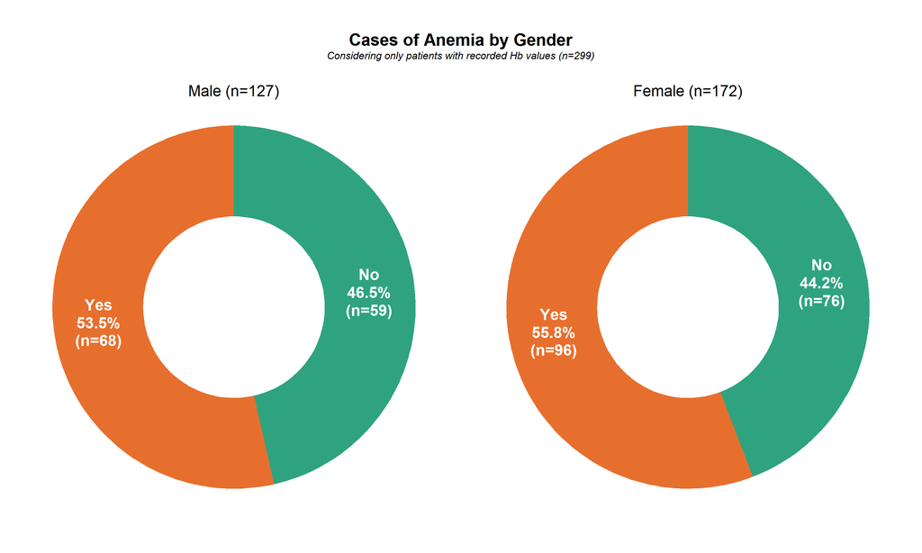

**By village**

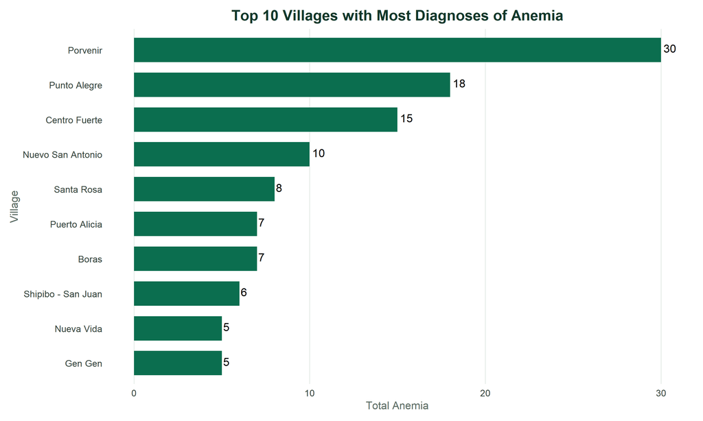

**TipHow Many Patients Presented with Hypertension?**

**General**

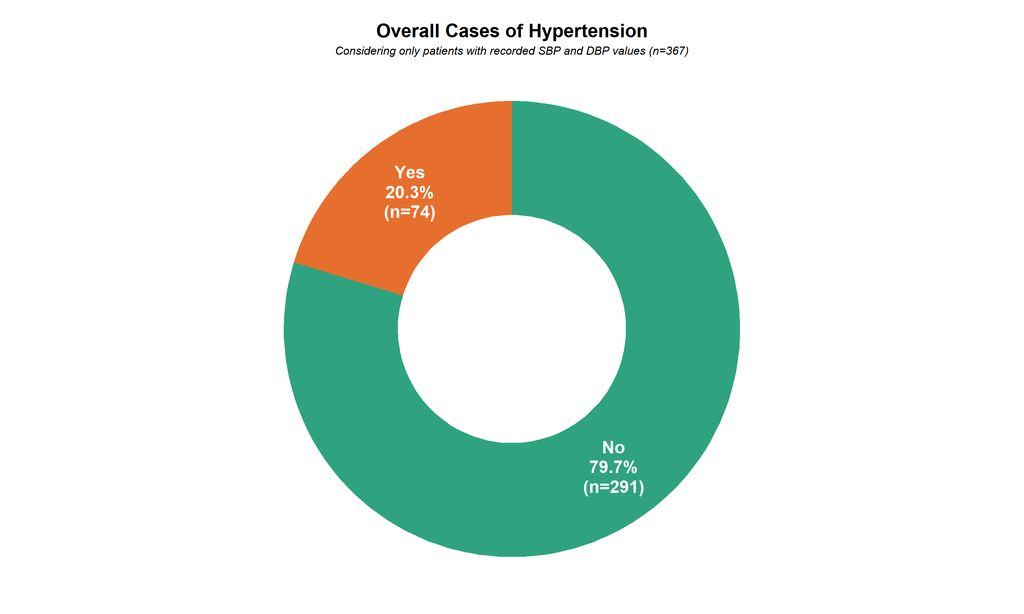

**By gender**

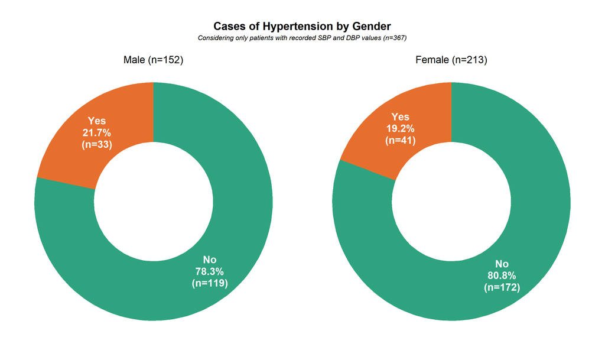

**TipHow Many Patients Presented with Diabetes Mellitus?**

**General**

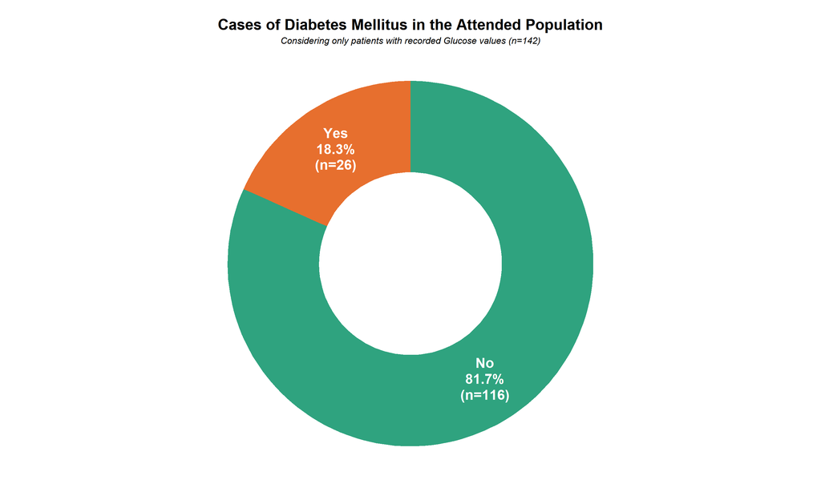

**By gender**

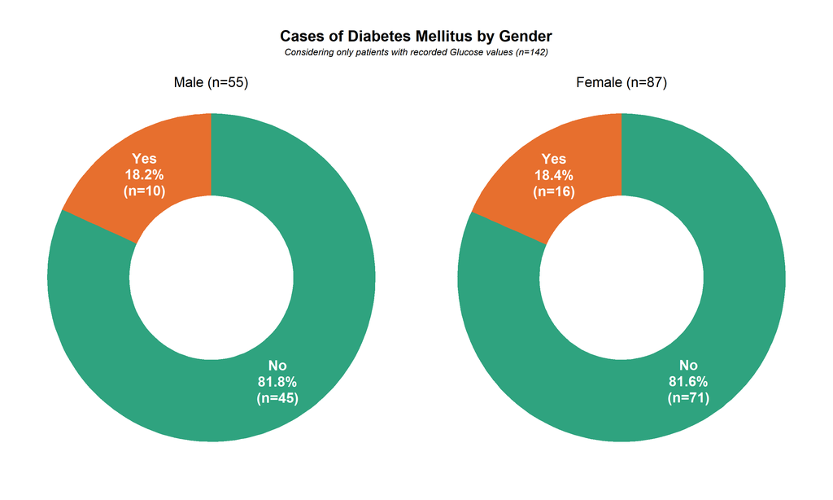

**TipHow Many Patients Presented with High Cholesterol?**

**General**

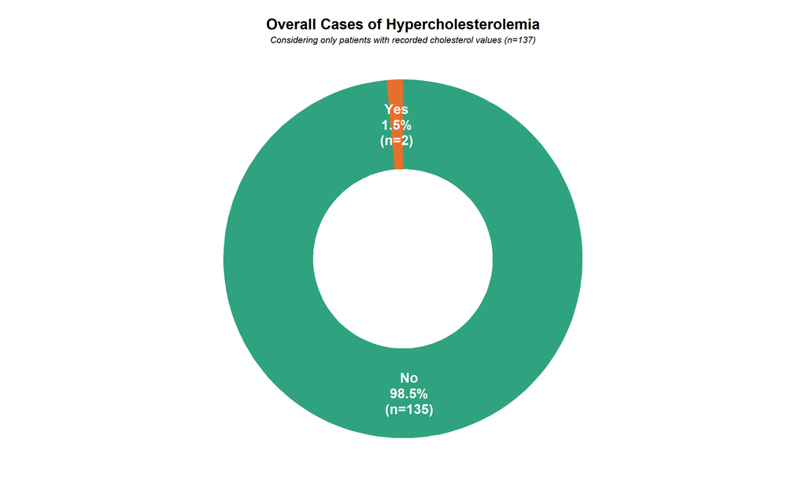

**By gender**

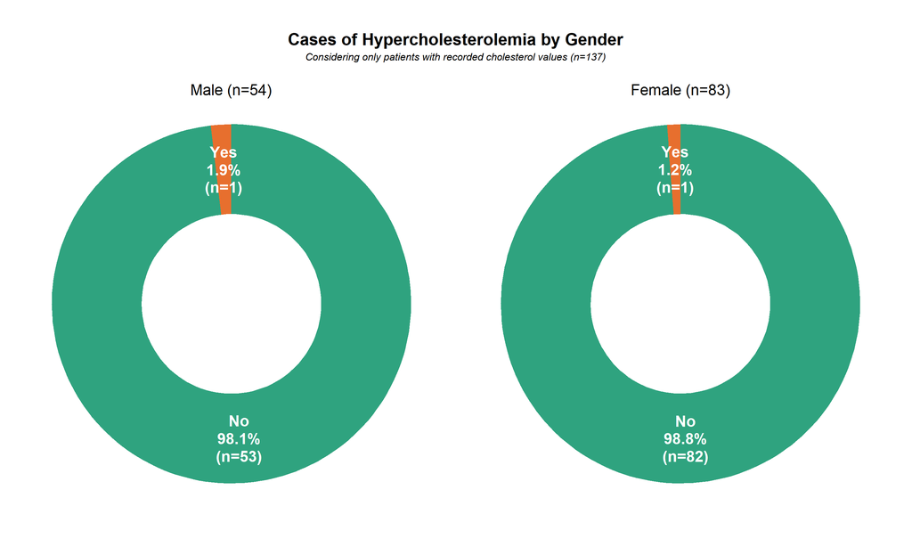

**TipHow Many Patients Presented with High Triglycerides?**

**General**

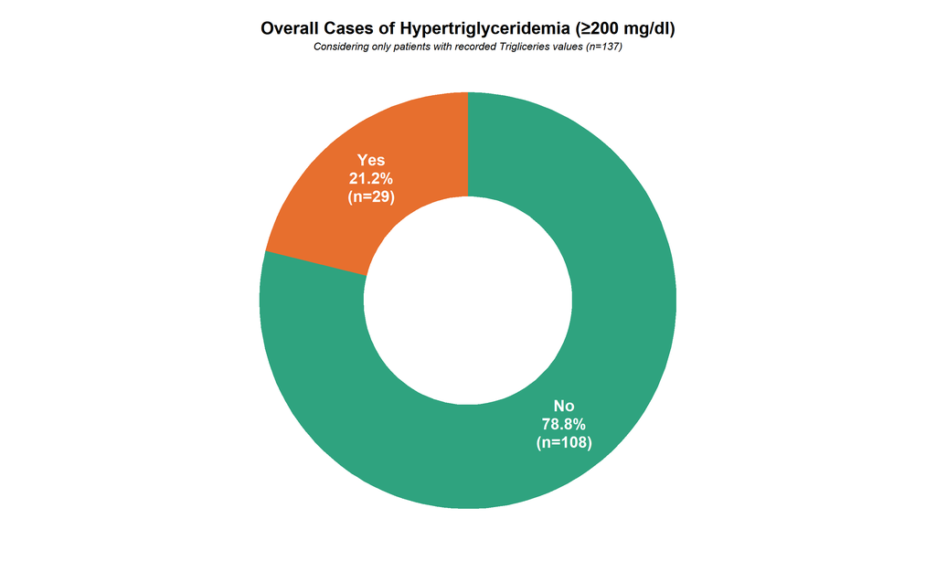

**By gender**

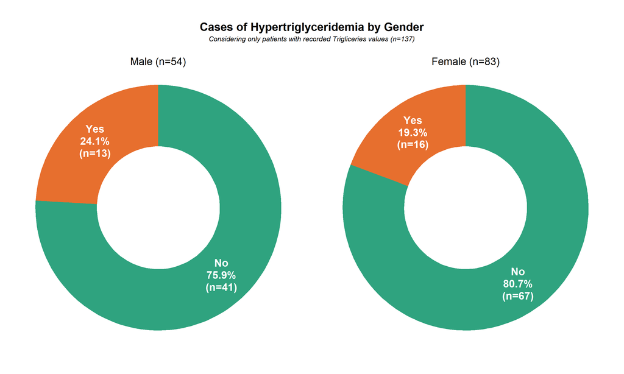

**TipSome lab values: Hemoglobin and Glucose values**

**General**

Hemoglobin and Glucose: Descriptive Statistics

| Lab | Mean | Median | Min | Max |
| --- | --- | --- | --- | --- |
| Hemoglobin | 12.13 | 12.1 | 8.2 | 16 |
| Glucose | 122.46 | 104.5 | 70.0 | 489 |

**By gender**

Descriptive Statistics of Hemoglobin and Glucose by Gender

| Gender | Lab | Mean | Median | Min | Max |
| --- | --- | --- | --- | --- | --- |
| Hemoglobin | Female | 11.99 | 12.0 | 9.4 | 14.6 |
| Hemoglobin | Male | 12.33 | 12.5 | 8.2 | 16.0 |
| Glucose | Female | 120.86 | 104.0 | 70.0 | 462.0 |
| Glucose | Male | 125.00 | 105.0 | 82.0 | 489.0 |

**By Age**

Descriptive Statistics of Hemoglobin and Glucose by Age Group

| Lab | Age Group | Mean | Median | Min | Max |
| --- | --- | --- | --- | --- | --- |
| Hemoglobin | <10y | 11.18 | 10.95 | 9.6 | 12.9 |
| Hemoglobin | 10-18y | 12.21 | 12.10 | 9.6 | 13.9 |
| Hemoglobin | 19-45y | 12.36 | 12.50 | 10.2 | 14.4 |
| Hemoglobin | 46-65y | 12.20 | 12.35 | 10.2 | 14.6 |
| Hemoglobin | >65y | 12.35 | 12.60 | 8.2 | 14.5 |
| Glucose | <10y | 122.00 | 100.00 | 98.0 | 168.0 |
| Glucose | 10-18y | 102.86 | 95.00 | 89.0 | 134.0 |
| Glucose | 19-45y | 142.38 | 107.00 | 88.0 | 462.0 |
| Glucose | 46-65y | 107.26 | 104.00 | 87.0 | 148.0 |
| Glucose | >65y | 119.30 | 105.00 | 84.0 | 237.0 |

**TipHow Many Patients Were Attended by Community?**

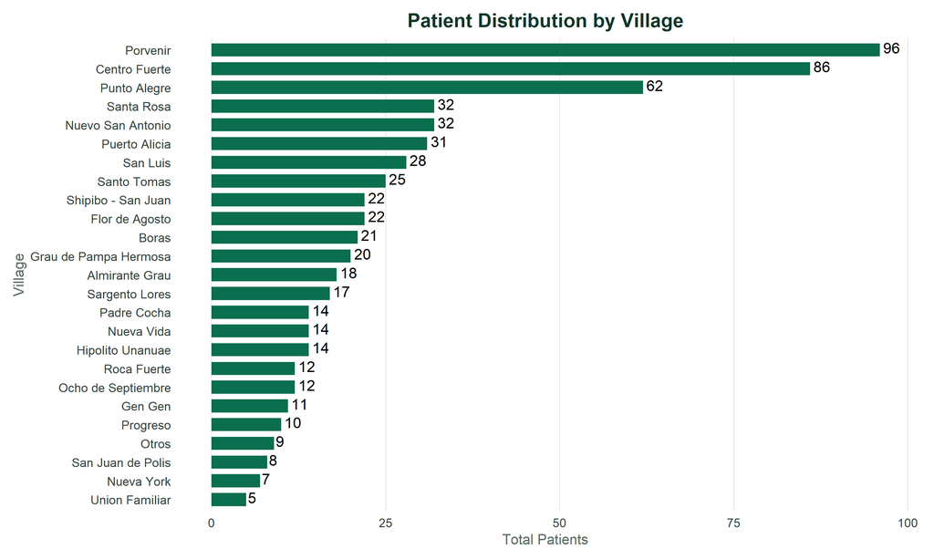

SIA Mission 2025 · PAMS · Statistical report generated on October 08, 2026 from the mission patient database.